# option price optimization

```python
train_sizes, train_scores, test_scores = learning_curve(
    rf_model, X_train, y_train, cv=5, scoring='accuracy', n_jobs=-1,
    train_sizes=np.linspace(0.1, 1.0, 10)
)
```

*Compute mean and std for train and test scores*

```python
train_scores_mean = np.mean(train_scores, axis=1)
test_scores_mean = np.mean(test_scores, axis=1)
```

*Plot learning curves*

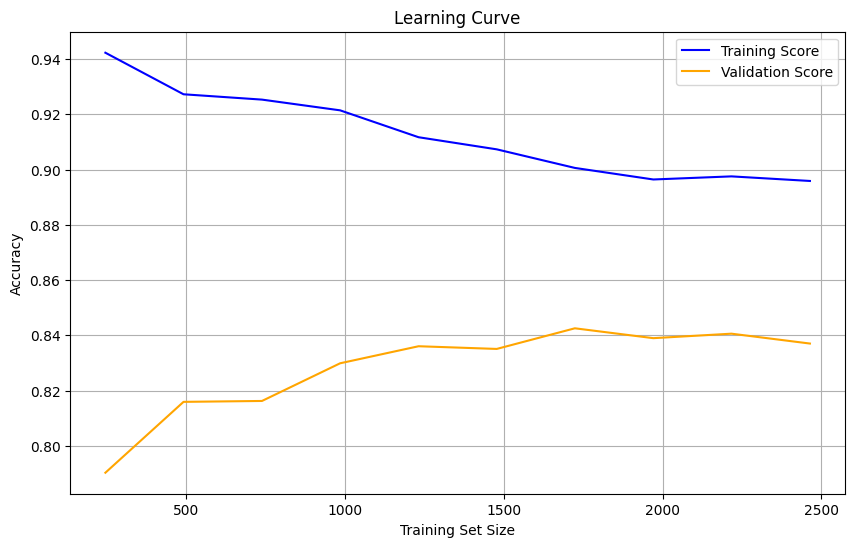

```python
plt.figure(figsize=(10, 6))
plt.plot(train_sizes, train_scores_mean, label='Training Score', color='blue')
plt.plot(train_sizes, test_scores_mean, label='Validation Score', color='orange')
plt.title('Learning Curve')
plt.xlabel('Training Set Size')
plt.ylabel('Accuracy')
plt.legend(loc='best')
plt.grid()
plt.show()
```

**Validation Curve**

```python
from sklearn.model_selection import validation_curve
```

*Define parameter range*

```python
param_range =[10, 50, 100, 200, 300]
```

*Generate validation curve for n_estimators*

```python
train_scores, test_scores = validation_curve(
    RandomForestClassifier(random_state=42),
    X_train, y_train,
    param_name='n_estimators',
    param_range=param_range,
    cv=5,scoring='accuracy', n_jobs=-1
)
```

*Compute mean and std for train and test scores*

```python
train_scores_mean = np.mean(train_scores, axis=1)
test__scores_mean = np.mean(test_scores, axis=1)
```

*Plot validation curve*

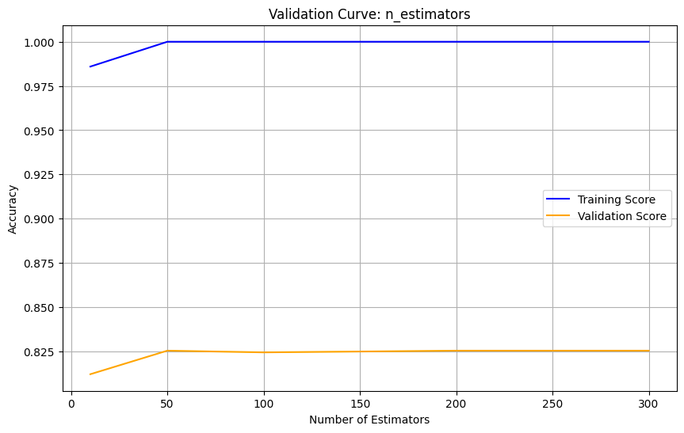

```python
param_range = [10, 50, 100, 200, 300]

train_scores, test_scores = validation_curve(
    RandomForestClassifier(random_state=42),
    X_train, y_train,
    param_name='n_estimators',
    param_range=param_range,
    cv=5, scoring='accuracy', n_jobs=-1
)

train_scores_mean = np.mean(train_scores, axis=1)
test_scores_mean = np.mean(test_scores, axis=1)

plt.figure(figsize=(10, 6))
plt.plot(param_range, train_scores_mean, label='Training Score', color='blue')
plt.plot(param_range, test_scores_mean, label='Validation Score', color='orange')
plt.title('Validation Curve: n_estimators')
plt.xlabel('Number of Estimators')
plt.ylabel('Accuracy')
plt.legend(loc='best')
plt.grid()
plt.show()
```

**Feature Selection**

```python
from sklearn.feature_selection import SelectFromModel
```

*Select important features*

```python
selector = SelectFromModel(rf_model, prefit=True)
X_train_reduced = selector.transform(X_train)
X_test_reduced = selector.transform(X_test)
```

*Train a new Random Forest on reduced features*

```python
rf_reduced = RandomForestClassifier(random_state=42)
rf_reduced.fit(X_train_reduced, y_train)
```

```
RandomForestClassifier(random_state=42)
```

*Evaluate reduced model*

```python
y_pred_reduced = rf_reduced.predict(X_test_reduced)
accuracy_reduced = accuracy_score(y_test, y_pred_reduced)
print(f"Accuracy with Reduced Features:{accuracy_reduced:.2f}")
```

```
Accuracy with Reduced Features:0.73
```

**Out-of-Bag(OOB) Error**

*Check OOB score*

```python
rf_model_oob = RandomForestClassifier(oob_score=True, random_state=42)
rf_model_oob.fit(X_train, y_train)
print(f"OOB Score: {rf_model_oob.oob_score_:.4f}")
```

```
OOB Score: 0.8260
```

**Grid Search for Hyperparameter Tuning**

```python
from sklearn.model_selection import GridSearchCV
```

*Define parameter grid*

```python
param_grid = {
    'n_estimators': [100, 200, 300],
    'max_depth':[10, 20, None],
    'min_samples_split':[2, 5, 10],
    'min_samples_leaf': [1, 2, 4],
    'max_features':['sqrt', 'log2', None]
}
```

*Initialize GridSearchCV*

```python
grid_search = GridSearchCV(
    estimator=RandomForestClassifier(random_state=42),
    param_grid=param_grid,
    cv=3, scoring='accuracy', n_jobs=-1, verbose=1
)
```

*Fit GridSearchCV*

```python
grid_search.fit(X_train, y_train)
```

```
Fitting 3 folds for each of 243 candidates, totalling 729 fits
```

```
GridSearchCV(cv=3, estimator=RandomForestClassifier(random_state=42), n_jobs=-1,
             param_grid={'max_depth': [10, 20, None],
                         'max_features': ['sqrt', 'log2', None],
                         'min_samples_leaf': [1, 2, 4],
                         'min_samples_split': [2, 5, 10],
                         'n_estimators': [100, 200, 300]},
             scoring='accuracy', verbose=1)
```

*Display best parameters*

```python
print(f"Best Parameters: {grid_search.best_params_}")
```

```
Best Parameters: {'max_depth': 10, 'max_features': 'sqrt', 'min_samples_leaf': 1, 'min_samples_split': 10, 'n_estimators': 200}
```

**Randomized Search for Faser Tuning**

```python
from sklearn.model_selection import RandomizedSearchCV
import scipy.stats  as stats
```

*Define parameter distribution*

```python
param_dist = {
    'n_estimators': stats.randint(50, 300),
    'max_depth': stats.randint(5, 50),
    'min_samples_split': stats.uniform(0.01, 0.1),
    'min_samples_leaf': stats.uniform(0.01, 0.1)
}
```

*Initialize RandomizedSearchCV*

```python
random_search = RandomizedSearchCV(
    estimator=RandomForestClassifier(random_state=42),
    param_distributions=param_dist,
    n_iter=100, cv=3, scoring='accuracy', n_jobs=-1, random_state=42
)
```

*Fit RandomizedSearchCV*

```python
random_search.fit(X_train, y_train)
```

```
RandomizedSearchCV(cv=3, estimator=RandomForestClassifier(random_state=42),
                   n_iter=100, n_jobs=-1,
                   param_distributions={'max_depth': <scipy.stats._distn_infrastructure.rv_discrete_frozen object at 0x000001FE8CA60C20>,
                                        'min_samples_leaf': <scipy.stats._distn_infrastructure.rv_continuous_frozen object at 0x000001FE8CA61730>,
                                        'min_samples_split': <scipy.stats._distn_infrastructure.rv_continuous_frozen object at 0x000001FE8CA29AF0>,
                                        'n_estimators': <scipy.stats._distn_infrastructure.rv_discrete_frozen object at 0x000001FE8CA2B6E0>},
                   random_state=42, scoring='accuracy')
```

*Display best parameters*

```python
print(f"Best Parameters: {random_search.best_params_}")
```

```
Best Parameters: {'max_depth': 13, 'min_samples_leaf': np.float64(0.01159662522202142), 'min_samples_split': np.float64(0.0330893825622149), 'n_estimators': 141}
```

**Analyze Predicted Probabilities**

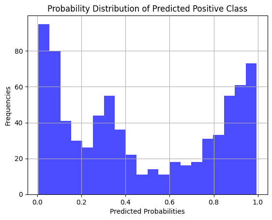

```python
y_pred_proba = rf_model.predict_proba(X_test)

plt.figure(figure=(10, 6))
plt.hist(y_pred_proba[:,1], bins=20, color='blue', alpha=0.7, label='Predicted Probabilities')
plt.title("Probability Distribution of Predicted Positive Class")
plt.xlabel('Predicted Probabilities')
plt.ylabel('Frequencies')
plt.grid()
plt.show()
```

**Confidence Interval of Model Accuracy**

```python
import numpy as np
from scipy.stats import sem, t

confidence = 0.95
n = len(cv_scores)
mean_acc = np.mean(cv_scores)
std_err = sem(cv_scores)
h = std_err * t.ppf((1 + confidence) / 2, n - 1)

print(f"Accuracy: {mean_acc:.4f} ± {h:.4f}")
```

```
Accuracy: 0.8370 ± 0.0173
```

**Compare Training and Validation/Test Performance to check for overfitting**

```python
from sklearn.metrics import accuracy_score, mean_squared_error


y_train_pred = rf_model.predict(X_train)
y_test_pred = rf_model.predict(X_test)

train_accuracy = accuracy_score(y_train, y_train_pred)
test_accuracy = accuracy_score(y_test, y_test_pred)

print(f"Training Accuracy: {train_accuracy}")
print(f"Test Accuracy: {test_accuracy}")

train_mse = mean_squared_error(y_train, y_train_pred)
test_mse = mean_squared_error(y_test, y_test_pred)

print(f"Training MSE: {train_mse}")
print(f"Test MSE: {test_mse}")
```

```
Training Accuracy: 0.8876623376623377
Test Accuracy: 0.8454545454545455
Training MSE: 0.11233766233766233
Test MSE: 0.15454545454545454
```

**Long-Short Term Memory Deep Learning Model**

**Data Preparation**

```python
import numpy as np
from sklearn.preprocessing import MinMaxScaler
from sklearn.model_selection import train_test_split
```

*Scale the features*

```python
scaler = MinMaxScaler()
X_scaled = scaler.fit_transform(X)
```

*Define the sequence Length*

```python
sequence_length = 10
```

*Convert data into sequences*

```python
def create_sequences(data, target, seq_length):
    X_seq, y_seq = [], []
    for i in range(len(data) - seq_length):
        X_seq.append(data[i:i+seq_length])
        y_seq.append(target[i+seq_length])
    return np.array(X_seq), np.array(y_seq)
```

```python
X_train, y_seq = create_sequences(X_scaled, y.values, sequence_length)
```

```python
X_seq, y_seq = create_sequences(X_scaled, y.values, sequence_length)
```

*Split the data into training and testing sets*

```python
X_train, X_test, y_train, y_test = train_test_split(X_seq, y_seq, test_size=0.2, random_state=42)


print("Training data shape:", X_train.shape)
print("Testing data shape:", X_test.shape)
```

```
Training data shape: (3072, 10, 7)
Testing data shape: (768, 10, 7)
```

**Build the LSTM Model**

```python
import tensorflow as tf
from tensorflow.keras.models import Sequential
from tensorflow.keras.layers import LSTM, Dense, Dropout
```

```python
model = Sequential([
    LSTM(50, return_sequences=True, input_shape=(X_train.shape[1], X_train.shape[2])),
    Dropout(0.2),
    LSTM(50, return_sequences=False),
    Dropout(0.2),
    Dense(1, activation='sigmoid')
])
```

```python
model.compile(optimizer='adam', loss='binary_crossentropy', metrics=['accuracy'])
```

*Summary of the model*

```python
model.summary()
```

```
Model: "sequential"
```

```
┏━━━━━━━━━━━━━━━━━━━━━━━━━━━━━━━━━┳━━━━━━━━━━━━━━━━━━━━━━━━┳━━━━━━━━━━━━━━━┓
┃ Layer (type)                    ┃ Output Shape           ┃       Param # ┃
┡━━━━━━━━━━━━━━━━━━━━━━━━━━━━━━━━━╇━━━━━━━━━━━━━━━━━━━━━━━━╇━━━━━━━━━━━━━━━┩
│ lstm (LSTM)                     │ (None, 10, 50)         │        11,600 │
├─────────────────────────────────┼────────────────────────┼───────────────┤
│ dropout (Dropout)               │ (None, 10, 50)         │             0 │
├─────────────────────────────────┼────────────────────────┼───────────────┤
│ lstm_1 (LSTM)                   │ (None, 50)             │        20,200 │
├─────────────────────────────────┼────────────────────────┼───────────────┤
│ dropout_1 (Dropout)             │ (None, 50)             │             0 │
├─────────────────────────────────┼────────────────────────┼───────────────┤
│ dense (Dense)                   │ (None, 1)              │            51 │
└─────────────────────────────────┴────────────────────────┴───────────────┘
```

```
 Total params: 31,851 (124.42 KB)
```

```
 Trainable params: 31,851 (124.42 KB)
```

```
 Non-trainable params: 0 (0.00 B)
```

**Train the model**

```python
history = model.fit(
    X_train, y_train,
    epochs=20,
    batch_size=32,
    validation_data=(X_test, y_test),
    verbose=2
)
```

```
96/96 - 8s - 87ms/step - accuracy: 0.6178 - loss: 0.6699 - val_accuracy: 0.7878 - val_loss: 0.5821
96/96 - 2s - 16ms/step - accuracy: 0.7972 - loss: 0.5166 - val_accuracy: 0.8021 - val_loss: 0.5000
96/96 - 2s - 17ms/step - accuracy: 0.8040 - loss: 0.4643 - val_accuracy: 0.8060 - val_loss: 0.4714
96/96 - 2s - 17ms/step - accuracy: 0.8128 - loss: 0.4362 - val_accuracy: 0.8047 - val_loss: 0.4390
96/96 - 2s - 16ms/step - accuracy: 0.8226 - loss: 0.4133 - val_accuracy: 0.8008 - val_loss: 0.4557
96/96 - 2s - 17ms/step - accuracy: 0.8271 - loss: 0.4023 - val_accuracy: 0.8125 - val_loss: 0.4234
96/96 - 2s - 16ms/step - accuracy: 0.8255 - loss: 0.3979 - val_accuracy: 0.8203 - val_loss: 0.4036
96/96 - 2s - 16ms/step - accuracy: 0.8268 - loss: 0.3948 - val_accuracy: 0.8151 - val_loss: 0.4040
96/96 - 2s - 16ms/step - accuracy: 0.8356 - loss: 0.3872 - val_accuracy: 0.8060 - val_loss: 0.4198
96/96 - 2s - 19ms/step - accuracy: 0.8275 - loss: 0.3942 - val_accuracy: 0.8216 - val_loss: 0.4042
96/96 - 2s - 22ms/step - accuracy: 0.8223 - loss: 0.3911 - val_accuracy: 0.8060 - val_loss: 0.4104
96/96 - 2s - 16ms/step - accuracy: 0.8330 - loss: 0.3808 - val_accuracy: 0.8138 - val_loss: 0.4098
96/96 - 2s - 16ms/step - accuracy: 0.8320 - loss: 0.3785 - val_accuracy: 0.8216 - val_loss: 0.3822
96/96 - 2s - 17ms/step - accuracy: 0.8356 - loss: 0.3773 - val_accuracy: 0.8216 - val_loss: 0.3833
96/96 - 1s - 16ms/step - accuracy: 0.8402 - loss: 0.3731 - val_accuracy: 0.8203 - val_loss: 0.3859
96/96 - 2s - 16ms/step - accuracy: 0.8330 - loss: 0.3872 - val_accuracy: 0.8346 - val_loss: 0.3852
96/96 - 2s - 17ms/step - accuracy: 0.8304 - loss: 0.3783 - val_accuracy: 0.8216 - val_loss: 0.3865
96/96 - 2s - 17ms/step - accuracy: 0.8369 - loss: 0.3683 - val_accuracy: 0.8398 - val_loss: 0.3807
96/96 - 2s - 19ms/step - accuracy: 0.8438 - loss: 0.3662 - val_accuracy: 0.8307 - val_loss: 0.3822
96/96 - 2s - 18ms/step - accuracy: 0.8415 - loss: 0.3702 - val_accuracy: 0.8307 - val_loss: 0.3870
```

**Evaluate the model**

```python
import matplotlib.pyplot as plt
```

*Evaluate the model*

```python
train_loss, train_acc = model.evaluate(X_train, y_train, verbose=0)
test_loss, test_acc = model.evaluate(X_test, y_test, verbose=0)
```

```python
print(f"Training Accuracy: {train_acc:.4f}")
print(f"Test Accuracy: {test_acc:.4f}")
```

```
Training Accuracy: 0.8519
Test Accuracy: 0.8307
```

*Plot training and validation accuracy*

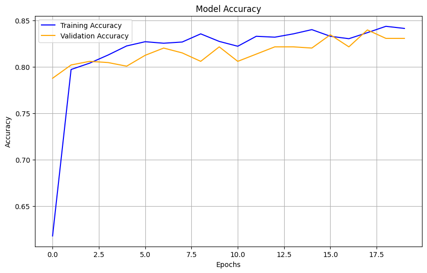

```python
plt.figure(figsize=(10, 6))
plt.plot(history.history['accuracy'], label='Training Accuracy', color='blue')
plt.plot(history.history['val_accuracy'], label='Validation Accuracy', color='orange')
plt.title('Model Accuracy')
plt.xlabel('Epochs')
plt.ylabel('Accuracy')
plt.legend(loc='best')
plt.grid()
plt.show()
```

**Predict and Interpret**

```python
y_pred = model.predict(X_test)
y_pred = (y_pred > 0.5).astype(int)

from sklearn.metrics import classification_report, confusion_matrix

print("Classification Report:")
print(classification_report(y_test, y_pred))

print("Confusion Matrix:")
print(confusion_matrix(y_test, y_pred))
```

```
24/24 ━━━━━━━━━━━━━━━━━━━━ 1s 9ms/step
Classification Report:
              precision    recall  f1-score   support

           0       0.82      0.86      0.84       392
           1       0.85      0.80      0.82       376

    accuracy                           0.83       768
   macro avg       0.83      0.83      0.83       768
weighted avg       0.83      0.83      0.83       768

Confusion Matrix:
[[337  55]
 [ 75 301]]
```

**Using Keras Tuner for Automated Tuning**

*Define the Model for Tuning*

```python
import tensorflow as tf
from tensorflow.keras import layers
import keras_tuner as kt
```

```python
def build_model(hp):
    model = tf.keras.Sequential()

    model.add(
        layers.LSTM(
            units=hp.Int("units", min_value=32, max_value=128, step=32),
            activation="relu",
            input_shape=(X_train.shape[1], X_train.shape[2]),
        )
    )

    model.add(layers.Dropout(rate=hp.Float("dropout", min_value=0.1, max_value=0.5, step=0.1)))

    model.add(layers.Dense(1, activation="sigmoid"))

    model.compile(
        optimizer=tf.keras.optimizers.Adam(
            learning_rate=hp.Float("learning_rate", min_value=1e-4, max_value=1e-2, sampling="log")
        ),
        loss="binary_crossentropy",
        metrics=["accuracy"],
    )

    return model
```

**Run the Hyperparameter Search**

```python
tuner = kt.Hyperband(
    build_model,
    objective="val_accuracy",
    max_epochs=10,
    factor=3,
    directory="lstm_tuning",
    project_name="price_movement",
)

tuner.search(X_train, y_train, epochs=10, validation_data=(X_test, y_test), verbose=2)
```

```
Reloading Tuner from lstm_tuning\price_movement\tuner0.json
```

```python
best_hps = tuner.get_best_hyperparameters(num_trials=1)[0]
print(f'The optimal number of LSTM units is {best_hps.get('units')}')
print(f'The optimal dropout rate is {best_hps.get('dropout')}')
```

```
The optimal number of LSTM units is 128
The optimal dropout rate is 0.2
```

**Retrain the model with Optimal Parameters**

```python
best_model = tuner.hypermodel.build(best_hps)

history = best_model.fit(X_train, y_train, epochs=20, validation_data=(X_test, y_test), verbose=2)

train_loss, train_acc = best_model.evaluate(X_train, y_train)
train_loss, test = best_model.evaluate(X_test, y_test)

print(f'Best Model Training Accutacy: {train_acc:.4f}')
print(f'Best Model Test Accuracy: {test_acc:.4f}')
```

```
96/96 - 7s - 72ms/step - accuracy: 0.7487 - loss: 0.5629 - val_accuracy: 0.7786 - val_loss: 0.5296
96/96 - 2s - 20ms/step - accuracy: 0.8128 - loss: 0.4446 - val_accuracy: 0.8268 - val_loss: 0.4209
96/96 - 2s - 18ms/step - accuracy: 0.8105 - loss: 0.4253 - val_accuracy: 0.7982 - val_loss: 0.4834
96/96 - 2s - 19ms/step - accuracy: 0.8376 - loss: 0.3793 - val_accuracy: 0.8307 - val_loss: 0.3910
96/96 - 2s - 19ms/step - accuracy: 0.8415 - loss: 0.3907 - val_accuracy: 0.8268 - val_loss: 0.4007
96/96 - 2s - 19ms/step - accuracy: 0.8402 - loss: 0.3793 - val_accuracy: 0.8333 - val_loss: 0.3986
96/96 - 2s - 22ms/step - accuracy: 0.8464 - loss: 0.3747 - val_accuracy: 0.8229 - val_loss: 0.3962
96/96 - 3s - 27ms/step - accuracy: 0.8389 - loss: 0.3773 - val_accuracy: 0.8190 - val_loss: 0.4172
96/96 - 2s - 24ms/step - accuracy: 0.8434 - loss: 0.3750 - val_accuracy: 0.8346 - val_loss: 0.3960
96/96 - 2s - 25ms/step - accuracy: 0.8431 - loss: 0.3762 - val_accuracy: 0.8385 - val_loss: 0.3900
96/96 - 2s - 19ms/step - accuracy: 0.8470 - loss: 0.3649 - val_accuracy: 0.8333 - val_loss: 0.3819
96/96 - 2s - 18ms/step - accuracy: 0.8454 - loss: 0.3680 - val_accuracy: 0.8359 - val_loss: 0.3783
96/96 - 2s - 17ms/step - accuracy: 0.8477 - loss: 0.3714 - val_accuracy: 0.8398 - val_loss: 0.3992
96/96 - 2s - 17ms/step - accuracy: 0.8451 - loss: 0.3735 - val_accuracy: 0.8333 - val_loss: 0.3813
96/96 - 2s - 24ms/step - accuracy: 0.8477 - loss: 0.3619 - val_accuracy: 0.8411 - val_loss: 0.3739
96/96 - 2s - 26ms/step - accuracy: 0.8467 - loss: 0.3657 - val_accuracy: 0.8372 - val_loss: 0.3764
96/96 - 3s - 29ms/step - accuracy: 0.8509 - loss: 0.3570 - val_accuracy: 0.8333 - val_loss: 0.3813
96/96 - 2s - 22ms/step - accuracy: 0.8483 - loss: 0.3569 - val_accuracy: 0.8398 - val_loss: 0.3782
96/96 - 2s - 19ms/step - accuracy: 0.8444 - loss: 0.3775 - val_accuracy: 0.8424 - val_loss: 0.4083
96/96 - 2s - 19ms/step - accuracy: 0.8376 - loss: 0.3759 - val_accuracy: 0.8359 - val_loss: 0.3926
96/96 ━━━━━━━━━━━━━━━━━━━━ 1s 14ms/step - accuracy: 0.8521 - loss: 0.3553
24/24 ━━━━━━━━━━━━━━━━━━━━ 0s 11ms/step - accuracy: 0.8362 - loss: 0.3882
Best Model Training Accutacy: 0.8512
Best Model Test Accuracy: 0.8307
```

**Model Back Testing**

**Prepare Predictions and Compare**

```python
predictions = best_model.predict(X_test)
```

```
24/24 ━━━━━━━━━━━━━━━━━━━━ 1s 14ms/step
```

```python
predictions = np.where(predictions > 0.5, 1, 0)
```

**Define the Backtesting Logic**

*Assume 'y_test' contains the true price price movements*

```python
initial_balance = 100000
balance = initial_balance
position = 0
portfolio_value = []

for i in range(1, len(X_test)):
    if predictions[i] == 1 and position == 0:
        position = 1
        balance -= tesla_options_data['lastPrice'].iloc[i]
    elif predictions[i] == 0 and position == 1:
        balance += tesla_options_data['lastPrice'].iloc[i]
        position = 0

    portfolio_value.append(balance + position * tesla_options_data['lastPrice'].iloc[i])

portfolio_value = np.array(portfolio_value)
```

**Evaluate the Perfomance**

```python
total_returns = (portfolio_value[-1] - portfolio_value[0]) / portfolio_value[0] * 100  # Total return as percentage

cumulative_returns = (portfolio_value / portfolio_value[0]) - 1

running_max = np.maximum.accumulate(portfolio_value)
drawdowns = (portfolio_value - running_max) / running_max
max_drawdown = np.min(drawdowns)

risk_free_rate = 0
excess_returns = portfolio_value - balance
sharpe_ratio = np.mean(excess_returns) / np.std(excess_returns)

print(f"Final Portfolio Value: ${portfolio_value[-1]:.2f}")
print(f"Total Return: {total_returns:.2f}%")
print(f"Maximum Drawdown: {max_drawdown:.2f}")
print(f"Sharpe Ratio: {sharpe_ratio:.2f}")
```

```
Final Portfolio Value: $100033.32
Total Return: 0.03%
Maximum Drawdown: -0.00
Sharpe Ratio: 0.08
```

**Visualize the Backtesting Results**

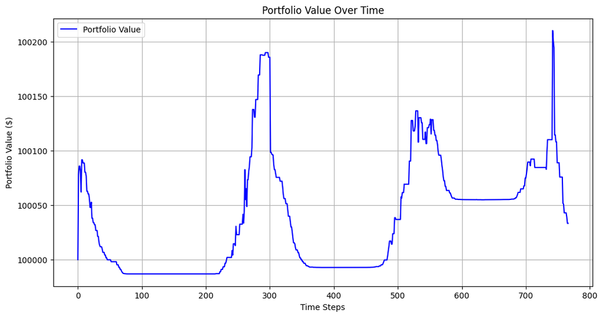

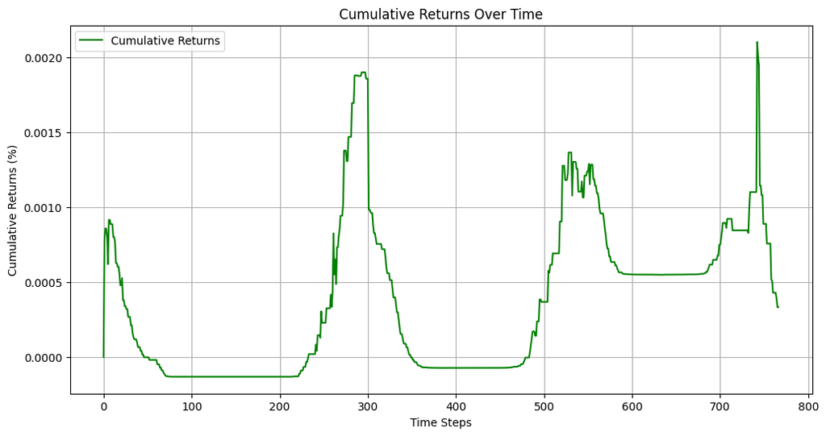

```python
plt.figure(figsize=(12, 6))
plt.plot(portfolio_value, label="Portfolio Value", color="blue")
plt.title("Portfolio Value Over Time")
plt.xlabel("Time Steps")
plt.ylabel("Portfolio Value ($)")
plt.legend(loc="upper left")
plt.grid(True)
plt.show()

plt.figure(figsize=(12, 6))
plt.plot(cumulative_returns, label="Cumulative Returns", color="green")
plt.title("Cumulative Returns Over Time")
plt.xlabel("Time Steps")
plt.ylabel("Cumulative Returns (%)")
plt.legend(loc="upper left")
plt.grid(True)
plt.show()
```

**Live Trading Strategy/Trading BOT**

**Import and Initial Setup**

```python
import alpaca_trade_api as tradeapi
import pandas as pd
import numpy as np
from keras.models import load_model
from datetime import datetime, timedelta
import time

API_KEY = 'CK0URE4ME9IZ2N7PJTKN'
SECRET_KEY = 'eAfPSyq5Jgs0aERi5ys1sZWIMFaoDZlv6Im7XP0u'
BASE_URL = 'https://broker-api.sandbox.alpaca.markets'

api = tradeapi.REST(API_KEY, SECRET_KEY, BASE_URL, api_version='v2')

SYMBOL = 'TSLA'
INITIAL_BALANCE = 100000
RISK_PER_TRADE = 0.01
PREDICTION_THRESHOLDB= 0.6
```

**Helper Functions**

*Real-time Data Fetching*

```python
from requests.exceptions import HTTPError

def get_realtime_data(symbol, lookback):
    """
    Fetch real-time data for the given symbol from Alpaca.
    Suggest upgrading to a paid plan if a 403 error is encountered.
    """
    try:
        end_time = pd.Timestamp.now(tz='UTC')
        start_time = end_time - pd.Timedelta(minutes=lookback)

        bars = api.get_bars(
            symbol,
            "1Min",
            start=start_time.isoformat(),
            end=end_time.isoformat(),
            adjustment='raw'
        ).df

        bars = bars[bars['symbol'] == symbol]
        return bars

    except HTTPError as e:
        if e.response.status_code == 403:
            print(
                f"Access to Alpaca's real-time data is restricted. "
                f"Please upgrade to a paid plan or verify your account permissions."
            )
        else:
            print(f"An unexpected error occurred: {e.response.status_code}")
        return None
```

*Preprocessing for Model Prediction*

```python
def preprocess_data(data):
    """
    Preprocess real-time data for LSTM model.
    :param data: DataFrame with real-time market data
    :return: Numpy array suitable for model input
    """

    features = data[['strike', 'bid', 'ask', 'volume', 'openInterst', 'impliedVolatility', 'inMoney']].values
    return np.expand_dims(features, axis=0)
```

*Trade Execution Logic*

```python
def execute_trade(signal, risk_per_trade, current_balance):
    """
     Execute a buy//sell order based on the signal.
     :param signal: 'buy' or 'sell'
     :param risk_per_trade: Fraction of prtfolio to risk
     :param current_balance: Current portfolio balance
     """
    position_size = (current_balance * risk_per_trade) / api.get_last_trade(SYMBOL).price

    if signal == 'buy':
        api.submit_order(
            symbol=SYMBOL,
            qty=position_size,
            side='buy',
            type='market',
            time__in_force='gtc'
        )

        print(f"Executed BUY order for {position_size:.4f} shares of {SYMBOL}")


    elif signal == 'sell':
        api.submit_order(
            symbol=SYMBOL,
            qty=position_size,
            side='sell',
            type='market',
            time_in_force='gtc'
        )

        print(f"Executed SELL order for {position_size:.4f} shares of {SYMBOL}")
```

**Main Live Trading Loop**

```python
model = best_model

balance = INITIAL_BALANCE
position = 0

print("Starting live trading...")

try:
    while True:
        try:
            data = get_realtime_data(SYMBOL, lookback=50)

            if data is None:
                print(f"[{datetime.now()}] No data fetched. Stopping live trading.")
                break

            processed_data = preprocess_data(data)

            prediction = model.predict(processed_data)
            predicted_movement = prediction[0][0]

            if predicted_movement > PREDICTION_THRESHOLD and position == 0:
                execute_trade('buy', RISK_PER_TRADE, balance)
                position = 0

                last_price = api.get_last_trade(SYMBOL).price
                balance = balance + (position * last_price)

                print(f"[{datetime.now()}] Balance: ${balance:.2f} | Position: {position} | Predicted Movement: {predicted_movement:.4f}")

            time.sleep(60)

        except tradeapi.rest.APIError as e:
            if e.status_code == 403:
                print("Error: Access forbidden. Please check your API keys or consider upgrading to a paid Alpaca plan.")
            else:
                print(f"API error encountered: {e}")
            time.sleep(60)

except KeyboardInterrupt:
    print("Live trading stopped by user.")
```

```
Starting live trading...
Access to Alpaca's real-time data is restricted. Please upgrade to a paid plan or verify your account permissions.
[2024-11-28 13:14:14.050347] No data fetched. Stopping live trading.
```

**Risk Management Enhancements**

```python
def stop_loss_take_profit(position, entry_price, stop_loss_pct=0.02, take_profit_pct=0.05):
    """
    Check stop-loss and take-profit levels.
    :param position: Current position (1 for long, 0 for no position)
    :param entry_price: Price at which the position was entered
    :param stop_loss_pct: Stop-loss percentage
    :param take_profit_pct: Take-profit percentage
      """
    last_price = api.get_last_trade(SYMBOL).price
    if position == 1:
        if last_price <=entry_price * (1 - take_profit_pct):
            print("Stop-loss triggered.")
            execute_trade('sell', RISK_PER_TRADE, balance)
            return 0
        elif last_price >=entry_price * (1 + take_profit_pct):
            print("Take-profit triggered.")
            execute_trade('sell', RISK_PER_TRADE, balance)
            return 0
        return position
```

*Integrate into the main loop:*

```python
if position == 1:
    position = stop_loss_take_profit(position, entry_price)
```

**Logs and Alerts**

```python
import logging

logging.basicConfig(filename='trading_log.txt', level=logging.INFO, format='%(asctime)s -%(message)s')

def log_trade(action, qty, price):
    logging.info(f"Action: {action}, Quantity: {qty:.4f}, Price: ${price:.2f}")
```